# **Scandals Revisited:** Reassessing the Relevance of Political Scandals for Electoral Performance

PPPC 2024, July 7, Cologne

Frederik  
Thieme

frederik.thieme@hu-berlin.de

Humboldt-Universität zu Berlin

July 3, 2024

# Motivation

- clear `public expectation` on the consequences of scandals
- theory: voters as `rational updaters`

[figure not shown]

Armin Laschet (CDU) in 2021 after severe floods in Germany in the election run-up

# Overview

- ❓ `Question`: How do scandals by district candidates impact their local electoral performance?
- 💡 `Argument`: highly relevant, less party constraints for sanction (dual-vote)
- 💾 `Data`: new scandal data set + election results (2009-2021)
- ️⚙️ `Method`: Difference-in-Differences
- 📊 `Results`:
  - no negative effect of scandal involvement
  - not altered by incumbency, salience or timing

# Data & Method

- scandals from Wikipedia lists & Lobbyreports
  - `38 scandals` by district candidates (2009-2021)
- `salience` by media coverage & Google trends
- Difference-in-differences estimation after Imai et al. (2021)
  - `matching` treatment with control observations
  - same party, year, state

# First Vote Results

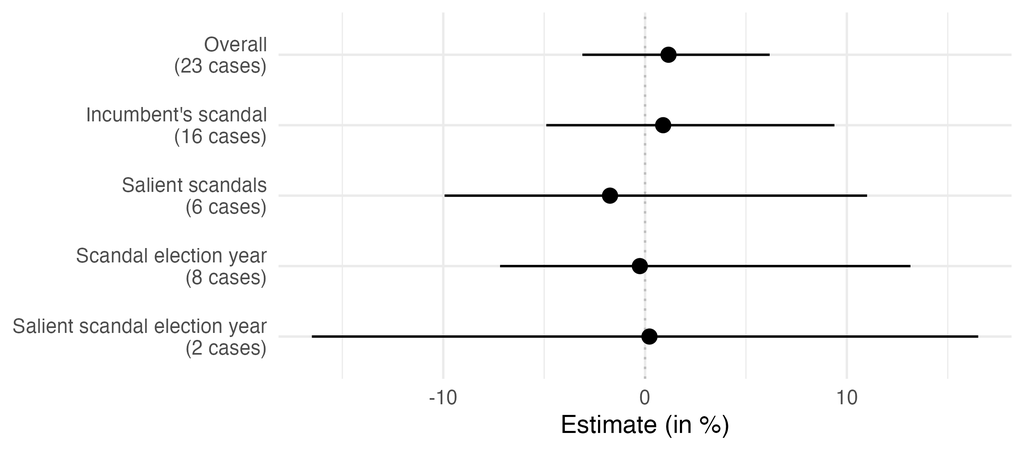

# Spillover Effects

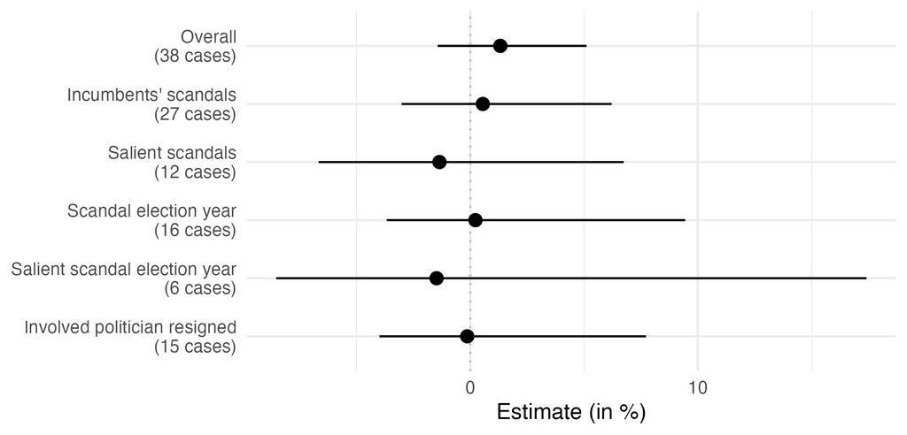

# Conclusion

- voters’ reactions to scandals do `not` fit `rational updater` view
- scandals as “new normal” (Pollack et al. 2018), “scandal fatigue” (Kumlin & Essaiasson, 2012), `"post-scandal era"` (von Sikorski & Kubin, 2021)
- no clear pattern in resignations
- `contribution`: beyond single cases, outside US, most likely case

# Thank you for your attention.

Questions or feedback? Hit me up:

- 🌐 [frederikthieme.net](https://frederikthieme.net/)
- 📥 frederik.thieme@hu-berlin.de
- 🟦 frederikthieme.bsky.social
- 🐦 frederik_thieme